# Human Activity Recognition: Predicting Dumbbells exercise actitivity

Vidit Agrawal

March 3, 2019

## Executive Summary

Using devices such as Nike FuelBand, and Fitbit a large amount of data about personal activity is available. One thing that people regularly do is quantify how much of a particular activity they do, but they rarely quantify how well they do it. The goal of this project is to perform Human activity recognition to predict “the quality of an activity”. The activity we are analysing is Unilateral Dumbbell Biceps Curl in five different fashions: exactly according to the specification (Class A), throwing the elbows to the front (Class B), lifting the dumbbell only halfway (Class C), lowering the dumbbell only halfway (Class D) and throwing the hips to the front (Class E). We use data from accelerometers on the belt, forearm, arm, and dumbell of 6 participants.

### Getting data

Before loading the data one must download the train and test data from following sources save them in working directory.

[Training data](https://d396qusza40orc.cloudfront.net/predmachlearn/pml-training.csv)

[Testing data](https://d396qusza40orc.cloudfront.net/predmachlearn/pml-testing.csv)

Loading the training and test Data

```r
training<-read.csv("training.csv",header=TRUE)
testing<-read.csv("testing.csv",header=TRUE)
library(caret)
library(rpart)
library(randomForest)
library(gbm)
```

### Cleaning data

First we check for NA values and removing features with NA values.

```r
NAFraction<-apply(training, 2, function(x) sum(is.na(x))/length(x))
NonNA_features<-NAFraction==0
sum(NonNA_features)
```

```
## [1] 93
```

```r
training<-training[NonNA_features]
testing<-testing[NonNA_features]
```

Next we check for features with blank values and removing those features.

```r
BlankFraction<-apply(training, 2, function(x) sum(x=="")/length(x))
NonBlank_features<-BlankFraction==0
sum(NonBlank_features==0)
```

```
## [1] 33
```

```r
training<-training[NonBlank_features]
testing<-testing[NonBlank_features]
```

Let’s look how the training data looks now.

```r
str(training)
```

```
## 'data.frame':    19622 obs. of  60 variables:
##  $ X                   : int  1 2 3 4 5 6 7 8 9 10 ...
##  $ user_name           : Factor w/ 6 levels "adelmo","carlitos",..: 2 2 2 2 2 2 2 2 2 2 ...
##  $ raw_timestamp_part_1: int  1323084231 1323084231 1323084231 1323084232 1323084232 1323084232 1323084232 1323084232 1323084232 1323084232 ...
##  $ raw_timestamp_part_2: int  788290 808298 820366 120339 196328 304277 368296 440390 484323 484434 ...
##  $ cvtd_timestamp      : Factor w/ 20 levels "02/12/2011 13:32",..: 9 9 9 9 9 9 9 9 9 9 ...
##  $ new_window          : Factor w/ 2 levels "no","yes": 1 1 1 1 1 1 1 1 1 1 ...
##  $ num_window          : int  11 11 11 12 12 12 12 12 12 12 ...
##  $ roll_belt           : num  1.41 1.41 1.42 1.48 1.48 1.45 1.42 1.42 1.43 1.45 ...
##  $ pitch_belt          : num  8.07 8.07 8.07 8.05 8.07 8.06 8.09 8.13 8.16 8.17 ...
##  $ yaw_belt            : num  -94.4 -94.4 -94.4 -94.4 -94.4 -94.4 -94.4 -94.4 -94.4 -94.4 ...
##  $ total_accel_belt    : int  3 3 3 3 3 3 3 3 3 3 ...
##  $ gyros_belt_x        : num  0 0.02 0 0.02 0.02 0.02 0.02 0.02 0.02 0.03 ...
##  $ gyros_belt_y        : num  0 0 0 0 0.02 0 0 0 0 0 ...
##  $ gyros_belt_z        : num  -0.02 -0.02 -0.02 -0.03 -0.02 -0.02 -0.02 -0.02 -0.02 0 ...
```

[output cut: 46 more lines]

We can see that first 7 columns represents the id, names, and timestamps related features. In my point of view these features should be excluded to train the prediction algorithm. We need to focus on values recorded by sensors to make prediction.

```r
training<-training[-c(1:7)]
testing<-testing[-c(1:7)]
```

### Analysis

We split the training dataset in training and validation set randomly with 60%:40% split. Doing it 10 randomizations we estimate the mean accuracy for the classification algorithm to find the best one.

Model # 1. Classification tree.

```r
set.seed(1234)
Accuracy_CART=rep(0,10)
for (i in 1:10){
  inTrain<-createDataPartition(training$classe, p = 0.6,list=FALSE)
  training_train<-training[ inTrain,]
  training_valid<-training[-inTrain,]
  modFit_CART <- rpart(classe ~ ., data=training_train, method="class")
  pred_CART <- predict(modFit_CART, training_valid, type = "class")
  Conf_CART<-confusionMatrix(pred_CART, training_valid$classe)
  Accuracy_CART[i]<-Conf_CART$overall[1]
}
```

Mean accuracy

```r
mean(Accuracy_CART)
```

```
## [1] 0.7299133
```

```r
set.seed(1234)
Accuracy_RF=rep(0,10)
for (i in 1:10){
  inTrain<-createDataPartition(training$classe, p = 0.6,list=FALSE)
  training_train<-training[ inTrain,]
  training_valid<-training[-inTrain,]
  modFit_RF <- randomForest(classe ~ ., data=training_train, ntree=10)
  pred_RF <- predict(modFit_RF, training_valid,type='class')
  Conf_RF<-confusionMatrix(pred_RF, training_valid$classe)
  Accuracy_RF[i]<-Conf_RF$overall[1]
}
```

Mean Accuracy

```r
mean(Accuracy_RF)
```

```
## [1] 0.986235
```

Model # 3. Generalized Boosting Model

```r
set.seed(1234)
Accuracy_GBM<-rep(0,10)
for (i in 1:10){
  modFit_GBM <- gbm(classe ~ ., data=training_train,n.trees = 10,verbose=FALSE,distribution="multinomial")
  Col_classe<-factor(c('A','B','C','D','E'))
  pred_GBM<- predict(modFit_GBM, training_valid,n.trees=10,type="response")
  pred_GBM<-Col_classe[apply(pred_GBM, 1,function(x) which(max(x)==x))]
  Conf_GBM<-confusionMatrix(pred_GBM, training_valid$classe)
  Accuracy_GBM[i]<-Conf_GBM$overall[1]
}
```

Mean accuracy

```r
mean(Accuracy_GBM)
```

```
## [1] 0.5926714
```

```r
set.seed(1234)
pred_RF_matrix<-matrix(nrow=length(training_valid[,1]),ncol=10)
for (i in 1:10){
  inTrain<-createDataPartition(training$classe, p = 0.6,list=FALSE)
  training_train<-training[ inTrain,]
  training_valid<-training[-inTrain,]
  modFit_RF <- randomForest(classe ~ ., data=training_train, ntree=10)
  pred_RF_matrix[,i] <- predict(modFit_RF, training_valid,type='class')
}
Pred_combine<-data.frame(pred_RF_matrix,training_valid$classe)
Model_Comb<-train(training_valid.classe~.,method="rf",ntree=10,data=Pred_combine)
Pred_Comb<-predict(Model_Comb,Pred_combine)
Conf_Comb<-confusionMatrix(Pred_Comb, training_valid$classe)
Conf_Comb
```

```
## Confusion Matrix and Statistics
##
##           Reference
## Prediction    A    B    C    D    E
##          A 2232    0    0    0    0
##          B    0 1518    0    0    0
##          C    0    0 1368    0    0
##          D    0    0    0 1286    0
##          E    0    0    0    0 1442
##
## Overall Statistics
##
##                Accuracy : 1
##                  95% CI : (0.9995, 1)
##     No Information Rate : 0.2845
##     P-Value [Acc > NIR] : < 2.2e-16
##
##                   Kappa : 1
##  Mcnemar's Test P-Value : NA
##
## Statistics by Class:
##
##                      Class: A Class: B Class: C Class: D Class: E
## Sensitivity            1.0000   1.0000   1.0000   1.0000   1.0000
## Specificity            1.0000   1.0000   1.0000   1.0000   1.0000
## Pos Pred Value         1.0000   1.0000   1.0000   1.0000   1.0000
## Neg Pred Value         1.0000   1.0000   1.0000   1.0000   1.0000
## Prevalence             0.2845   0.1935   0.1744   0.1639   0.1838
## Detection Rate         0.2845   0.1935   0.1744   0.1639   0.1838
## Detection Prevalence   0.2845   0.1935   0.1744   0.1639   0.1838
## Balanced Accuracy      1.0000   1.0000   1.0000   1.0000   1.0000
```

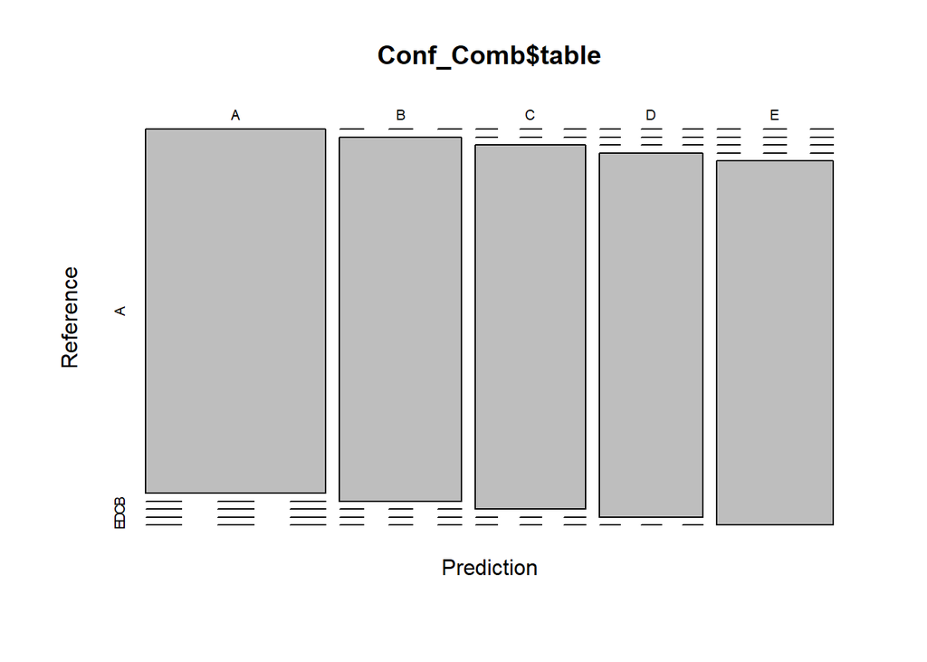

```r
plot(Conf_Comb$table)
```

```r
Accuracy_Comb<-Conf_Comb$overall[1]
Accuracy_Comb*100
```

```
## Accuracy
##      100
```

```r
Out_ofSample_Error<-(1-Accuracy_Comb)*100
print(Out_ofSample_Error)
```

```
## Accuracy
##        0
```

Finally, making prediction on the testing dataset.

```r
set.seed(1234)
pred_RF_test<-matrix(nrow=length(testing[,1]),ncol=10)
inTrain<-createDataPartition(training$classe, p = 0.6,list=FALSE)
training_train<-training[ inTrain,]
modFit_RF <- randomForest(classe ~ ., data=training_train, ntree=10)
pred_RF_test <- predict(modFit_RF, testing,type='class')
```

### Source

The data for this project come from this source:

[Velloso, E.; Bulling, A.; Gellersen, H.; Ugulino, W.; Fuks, H. Qualitative Activity Recognition of Weight Lifting Exercises. Proceedings of 4th International Conference in Cooperation with SIGCHI (Augmented Human ’13) . Stuttgart, Germany: ACM SIGCHI, 2013.](http://groupware.les.inf.puc-rio.br/har)